# HW2

Use this R Notebook document to answer the questions and document your work. Enter the R code used to answer each question in the corresponding R code chunk. Write any textual explanations **outside** of the chunks. When we grade, we will *hide* the code and just look at the R output and your written answers. Attempt to clean up your code as much as possible so that only the necessary lines remain.

When you are done:

1. Select ‘Run All’ from the ‘Run’ dropdown menu.
2. Save (File -> Save)
3. Click ‘Preview’ to bring up the `HW2.nb.html` file. Check through this to make sure it rendered correctly.
4. Upload the files: `HW2.nb.html` and `HW2.Rmd` to Canvas.

# 1 Part 1

## 1.1 Experiment

A researcher is interested in the difference in root growth between two wheat varieties. She plants 16 seeds of each variety in a completely randomized design and harvests the roots after 1 week. She records the root length (cm) of each plant.

```
'data.frame':   32 obs. of  3 variables:
 $ Plant      : int  1 2 3 4 5 6 7 8 9 10 ...
 $ Variety    : Factor w/ 2 levels "A","B": 1 1 1 1 2 2 1 2 1 1 ...
 $ Root_length: num  17.8 21.7 19.3 17.3 12.5 16.6 19.7 19 17.7 18.7 ...
```

| Plant | Variety | Root_length |
| --- | --- | --- |
| 1 | A | 17.8 |
| 2 | A | 21.7 |
| 3 | A | 19.3 |
| 4 | A | 17.3 |
| 5 | B | 12.5 |
| 6 | B | 16.6 |
| 7 | A | 19.7 |
| 8 | B | 19.0 |
| 9 | A | 17.7 |
| 10 | A | 18.7 |

[output cut: 22 more lines]

### 1.1.1 Describe the design of this experiment in detail.

Use the following table. You can also fill out the table in an excel document, and then paste it into [this website](http://www.tablesgenerator.com/markdown_tables) to generate the Markdown table.

**Level of Replication**: Treatment levels

| Structure | Variable | Type | # levels | Replicate | Experimental Unit |
| --- | --- | --- | --- | --- | --- |
| Treatment | Variety | Factor | 2 | None | Plant |
| Design | Plant | Factor | 32 |  |  |
| Response | Root_length | Numeric | 32 |  |  |

### 1.1.2 Do any columns of `data_1` need to be changed to be consistent with the design table?

Yes. Our plant numbers, as they are descriptive/categorical, should be formatted as `chr` or `fctr`. I’m going to use `chr` since they are all unique and do not need a finite number of categorical values.

Make any necessary changes here:

```
'data.frame':   32 obs. of  3 variables:
 $ Plant      : chr  "1" "2" "3" "4" ...
 $ Variety    : Factor w/ 2 levels "A","B": 1 1 1 1 2 2 1 2 1 1 ...
 $ Root_length: num  17.8 21.7 19.3 17.3 12.5 16.6 19.7 19 17.7 18.7 ...
```

### 1.1.3 Write the linear model for this experiment using the R function `lm()` or `lmer()` as appropriate:

Explain why you chose `lm()` or `lmer()`

```
Call:
lm(formula = Root_length ~ Variety, data = data_1)

Coefficients:
(Intercept)     VarietyB
     19.119       -3.469
```

I chose `lm()` given that there were no random variables in this experiment.

### 1.1.4 Make the model diagnostic plots shown in lab. Is there reason to be concerned about any of the model assumptions?

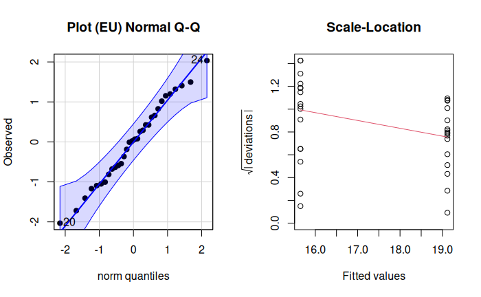

### 1.1.5 User the `emmeans()` and `contrast()` functions to estimate the difference in root lengths between the two varieties

Report a 90% confidence interval for the difference

```
 contrast estimate    SE df lower.CL upper.CL t.ratio p.value
 A - B        3.47 0.817 30     2.08     4.86   4.244  0.0002

Confidence level used: 0.9
```

Difference in root length is around 3.47, with a CI of 2.08 to 4.86.

## 1.2 Repeat this analysis “by hand”

The next few questions ask you to repeat the analysis withing using the modeling functions `lm()` and `emmeans` to show that you understand the mechanisms underlying the analysis

To help you analyze this data, I’ve separated out the data from each variety into a vector:

Use the variables `Variety_A` and `Variety_B` below for your calculations.

For the following 4 questions, you can check your answers below with the `t.test` function, but you must write out the calculations by hand. You can use functions like `mean()` and `sd()`, `qt`, etc.

### 1.2.1 Estimate the difference in root lengths between the two varieties

```
[1] 3.46875
```

The difference appears to be 3.47 (which matches, hooray!)

### 1.2.2 Estimate the Standard Error of this difference. Assume the variances of the two varieties are the same, and find a pooled estimate of the variance.

```
[1] 0.8173748
```

Standard error is 0.817

### 1.2.3 Form a 90% confidence interval for this difference

```
[1] 1.697261
[1] 2.081452
[1] 4.856048
```

T-sub-c is 1.70, and the Confidence Interval runs from 2.08 to 4.86